[figure not shown]

# CHARISMA: Script for Round Robin Polystyrene analysis

```python
from ramanchada.classes import RamanChada, SpectrumGroup
```

## First, let's do all steps by hand

### Determine the Silicon measured 520.45 cm-1 peak positions for a given laser power

Load Si SOP file

```python
file = r"\\vm-stor-51\alle\Projekte Kunststoffe\RD\MA\Öffentliche_Projekte\2020-01-07_230007_H2020-CHARISMA_barton\Round Robin 21\silicon\S0P_WITEcAlpha532_100x_100_10000msx1.spc"
```

```python
SOP = RamanChada(file)
```

```
x-y(1)
```

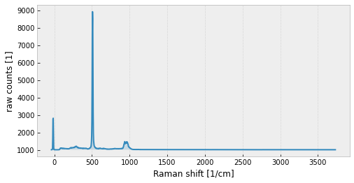

```python
SOP.plot()
```

Crop to ROI

```python
SOP.x_crop(200,1200)
```

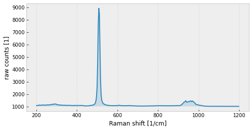

```python
SOP.plot()
```

```python
SOP.normalize('minmax')
```

Fit main peak: Voigt model in interval of 2x FWHM

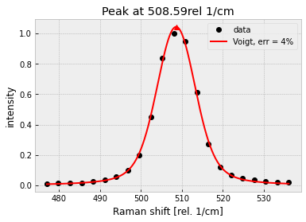

```python
SOP.peaks(fitmethod='voigt', x_min=400, x_max=600, show=True, interval_width=2)
```

```python
SOP.bands
```

[output not shown]

Calculate constant x shift from Si peak position

```python
sop_shift = 520.45 - SOP.bands['voigt fitted position'][0]
sop_shift
```

```
11.858741627369625
```

#### The same steps are performed for all Si types

```python
file = r"\\vm-stor-51\alle\Projekte Kunststoffe\RD\MA\Öffentliche_Projekte\2020-01-07_230007_H2020-CHARISMA_barton\Round Robin 21\silicon\S1N_WITEcAlpha532_100x_100_10000msx1.spc"
```

```python
S1N = RamanChada(file)
```

```
x-y(1)
```

```python
S1N.x_crop(200,1200)
```

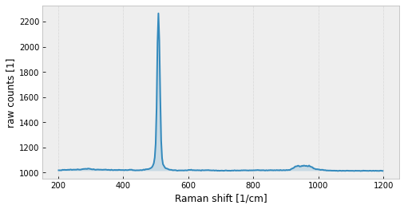

```python
S1N.plot()
```

```python
S1N.normalize('minmax')
```

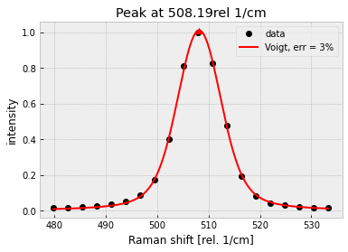

```python
S1N.peaks(fitmethod='voigt', x_min=400, x_max=600, show=True, interval_width=2)
```

```python
S1N.bands
```

|  | position | intensity | prominence | FWHM | Gauss area | voigt fitted position | voigt fitted FWHM | voigt fitted area |
| --- | --- | --- | --- | --- | --- | --- | --- | --- |
| 0 | 508.007355 | 1.0 | 0.99858 | 17.31884 | 18.435491 | 508.19171 | 7.160489 | 12.683663 |

```python
s1n_shift = 520.45 - S1N.bands['voigt fitted position'][0]
s1n_shift
```

```
12.258289948884453
```

```python
file = r"\\vm-stor-51\alle\Projekte Kunststoffe\RD\MA\Öffentliche_Projekte\2020-01-07_230007_H2020-CHARISMA_barton\Round Robin 21\silicon\SOB_WITEcAlpha532_100x_100_10000msx1.spc"
```

```python
SOB = RamanChada(file)
```

```
x-y(1)
```

```python
SOB.x_crop(200,1200)
```

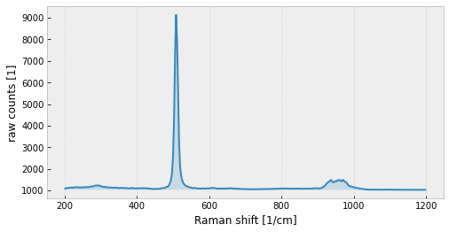

```python
SOB.plot()
```

```python
SOB.normalize('minmax')
```

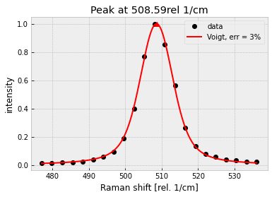

```python
SOB.peaks(fitmethod='voigt', x_min=400, x_max=600, show=True, interval_width=2)
```

```python
SOB.bands
```

|  | position | intensity | prominence | FWHM | Gauss area | voigt fitted position | voigt fitted FWHM | voigt fitted area |
| --- | --- | --- | --- | --- | --- | --- | --- | --- |
| 0 | 508.007355 | 1.0 | 0.996414 | 17.593159 | 18.727497 | 508.591258 | 9.026032 | 13.909884 |

```python
sob_shift = 520.45 - SOB.bands['voigt fitted position'][0]
sob_shift
```

```
11.858741627369625
```

SOB and SOP position are oddly identical. Check if spectra are identical:

```python
G = SpectrumGroup([SOB, SOP])
```

```python
%matplotlib notebook
```

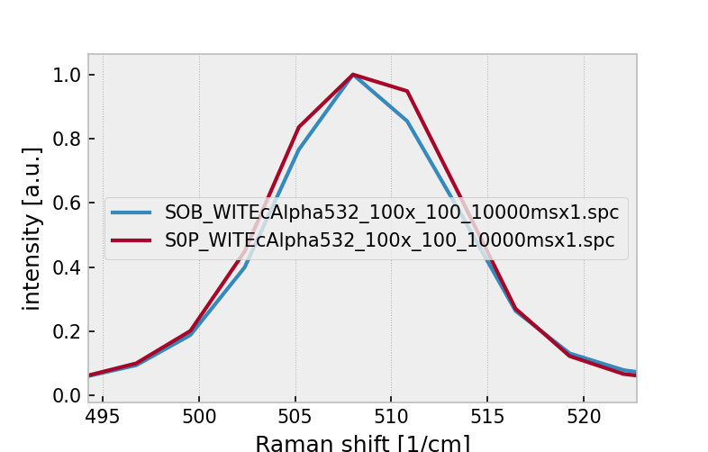

```python
G.plot()
```

#### Now, we can make a nice table for the current laser power

```python
Si = pd.DataFrame({'SOB': SOB.bands['voigt fitted position'][0],
                  'S1N': S1N.bands['voigt fitted position'][0],
                  'SOP': SOP.bands['voigt fitted position'][0]},
                  index=['Silicon measured 520.45 cm-1 peak position'])
```

```python
Si
```

|  | SOB | S1N | SOP |
| --- | --- | --- | --- |
| Silicon measured 520.45 cm-1 peak position | 508.591258 | 508.19171 | 508.591258 |

### Determine Polystyrene peak positions for a given laser power

```python
file = r"\\vm-stor-51\alle\Projekte Kunststoffe\RD\MA\Öffentliche_Projekte\2020-01-07_230007_H2020-CHARISMA_barton\Round Robin 21\polystyrene\spectra\27 polystyrene.spc"
```

```python
PS = RamanChada(file)
```

```
x-y(1)
```

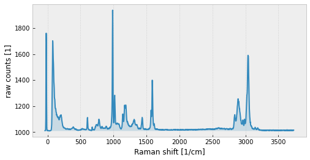

```python
PS.plot()
```

```python
PS.x_crop(250,3200)
```

```python
PS.normalize('minmax')
```

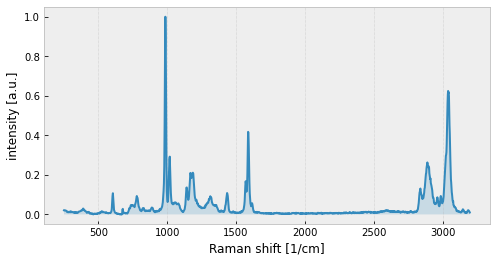

```python
PS.plot()
```

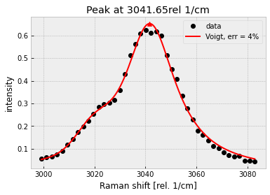

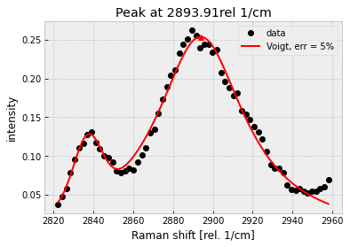

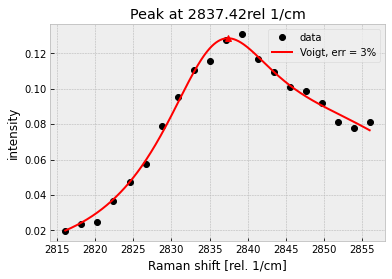

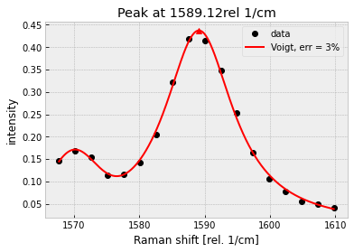

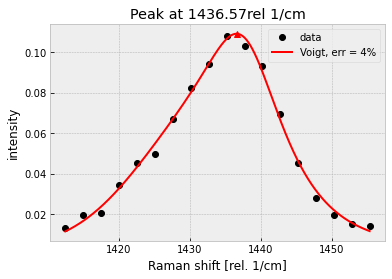

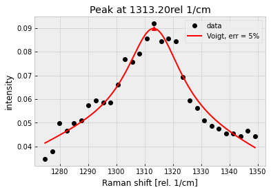

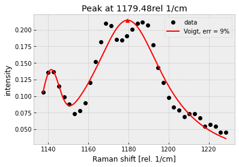

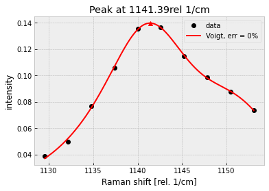

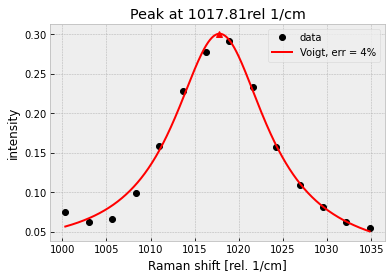

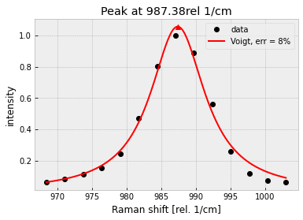

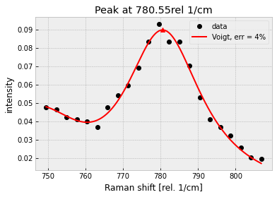

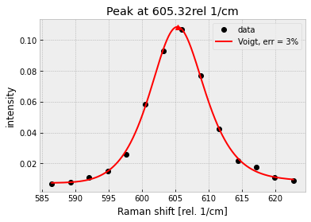

```python
PS.peaks(fitmethod='vg', show=True, interval_width=1.5, sort_by='position')
```

```python
PS.bands
```

|  | position | intensity | prominence | FWHM | Gauss area | vg fitted position | vg fitted FWHM | vg fitted area |
| --- | --- | --- | --- | --- | --- | --- | --- | --- |
| 0 | 3042.167480 | 0.612554 | 0.824928 | 28.749315 | 30.602958 | 3041.652551 | 24.070187 | 22.387625 |
| 1 | 2891.534424 | 0.255411 | 0.283406 | 46.994584 | 50.024610 | 2893.906052 | 45.875416 | 17.695987 |
| 2 | 2837.115967 | 0.127706 | 0.057290 | 14.268106 | 15.188058 | 2837.416673 | 13.256594 | 3.324309 |
| 3 | 1589.987915 | 0.414502 | 0.465180 | 18.604028 | 19.803543 | 1589.123619 | 9.864644 | 7.963166 |
| 4 | 1435.180420 | 0.108225 | 0.114486 | 19.542180 | 20.802183 | 1436.573192 | 17.171287 | 2.297396 |
| 5 | 1313.268066 | 0.091991 | 0.074791 | 32.614561 | 34.717420 | 1313.204682 | 24.919448 | 4.480796 |
| 6 | 1184.317993 | 0.209957 | 0.255675 | 39.997934 | 42.576844 | 1179.477732 | 28.829196 | 11.299555 |
| 7 | 1142.625000 | 0.136364 | 0.051308 | 11.238143 | 11.962735 | 1141.392810 | 8.966049 | 2.259184 |
| 8 | 1018.928406 | 0.292208 | 0.276407 | 17.139139 | 18.244203 | 1017.809115 | 11.268676 | 5.061784 |
| 9 | 987.050537 | 1.000000 | 0.994569 | 17.021104 | 18.118558 | 987.381894 | 8.824595 | 13.181055 |
| 10 | 779.579895 | 0.093074 | 0.095590 | 25.724434 | 27.383045 | 780.547672 | 16.228542 | 2.982210 |
| 11 | 605.984802 | 0.107143 | 0.097726 | 17.664646 | 18.803593 | 605.316619 | 9.398717 | 1.375849 |

Define reference peak positions for PS and sort (descending)

```python
ps_peak_pos = [221,
407,
543,
620.9,
795.8,
1001.4,
1031.8,
1155.3,
1450.5,
1583.1,
1602.3,
2852.4,
2904.5,
3054.3]
```

```python
ps_peak_pos.sort(reverse=True)
```

```python
PS.bands['PS position'] = np.nan
```

```python
for pos in ps_peak_pos:
    index = np.argmin(np.abs(PS.bands['position']-pos))
    PS.bands['PS position'][index] = pos
```

```python
PS.bands
```

|  | position | intensity | prominence | FWHM | Gauss area | vg fitted position | vg fitted FWHM | vg fitted area | PS position |
| --- | --- | --- | --- | --- | --- | --- | --- | --- | --- |
| 0 | 3042.167480 | 0.612554 | 0.824928 | 28.749315 | 30.602958 | 3041.652551 | 24.070187 | 22.387625 | 3054.3 |
| 1 | 2891.534424 | 0.255411 | 0.283406 | 46.994584 | 50.024610 | 2893.906052 | 45.875416 | 17.695987 | 2904.5 |
| 2 | 2837.115967 | 0.127706 | 0.057290 | 14.268106 | 15.188058 | 2837.416673 | 13.256594 | 3.324309 | 2852.4 |
| 3 | 1589.987915 | 0.414502 | 0.465180 | 18.604028 | 19.803543 | 1589.123619 | 9.864644 | 7.963166 | 1583.1 |
| 4 | 1435.180420 | 0.108225 | 0.114486 | 19.542180 | 20.802183 | 1436.573192 | 17.171287 | 2.297396 | 1450.5 |
| 5 | 1313.268066 | 0.091991 | 0.074791 | 32.614561 | 34.717420 | 1313.204682 | 24.919448 | 4.480796 | NaN |
| 6 | 1184.317993 | 0.209957 | 0.255675 | 39.997934 | 42.576844 | 1179.477732 | 28.829196 | 11.299555 | NaN |
| 7 | 1142.625000 | 0.136364 | 0.051308 | 11.238143 | 11.962735 | 1141.392810 | 8.966049 | 2.259184 | 1155.3 |
| 8 | 1018.928406 | 0.292208 | 0.276407 | 17.139139 | 18.244203 | 1017.809115 | 11.268676 | 5.061784 | 1031.8 |
| 9 | 987.050537 | 1.000000 | 0.994569 | 17.021104 | 18.118558 | 987.381894 | 8.824595 | 13.181055 | 1001.4 |
| 10 | 779.579895 | 0.093074 | 0.095590 | 25.724434 | 27.383045 | 780.547672 | 16.228542 | 2.982210 | 795.8 |
| 11 | 605.984802 | 0.107143 | 0.097726 | 17.664646 | 18.803593 | 605.316619 | 9.398717 | 1.375849 | 221.0 |

Put everything together in new DataFrame

```python
import pandas as pd
```

```python
RR = pd.DataFrame()
RR['Polystyrene peak positions'] = PS.bands['PS position']
RR['Measured positions'] = PS.bands['vg fitted position']
RR['Deviation'] = RR['Measured positions'] - RR['Polystyrene peak positions']
```

Add Si-adjusted deviations

```python
RR['Deviation after S0B adjustment'] = RR['Deviation'] + sob_shift
RR['Deviation after S1N adjustment'] = RR['Deviation'] + s1n_shift
RR['Deviation after S0P adjustment'] = RR['Deviation'] + sop_shift
```

```python
RR
```

|  | Polystyrene peak positions | Measured positions | Deviation | Deviation after S0B adjustment | Deviation after S1N adjustment | Deviation after S0P adjustment |
| --- | --- | --- | --- | --- | --- | --- |
| 0 | 3054.3 | 3041.652551 | -12.647449 | -0.788707 | -0.389159 | -0.788707 |
| 1 | 2904.5 | 2893.906052 | -10.593948 | 1.264793 | 1.664342 | 1.264793 |
| 2 | 2852.4 | 2837.416673 | -14.983327 | -3.124586 | -2.725038 | -3.124586 |
| 3 | 1583.1 | 1589.123619 | 6.023619 | 17.882360 | 18.281909 | 17.882360 |
| 4 | 1450.5 | 1436.573192 | -13.926808 | -2.068066 | -1.668518 | -2.068066 |
| 5 | NaN | 1313.204682 | NaN | NaN | NaN | NaN |
| 6 | NaN | 1179.477732 | NaN | NaN | NaN | NaN |
| 7 | 1155.3 | 1141.392810 | -13.907190 | -2.048448 | -1.648900 | -2.048448 |
| 8 | 1031.8 | 1017.809115 | -13.990885 | -2.132144 | -1.732595 | -2.132144 |
| 9 | 1001.4 | 987.381894 | -14.018106 | -2.159364 | -1.759816 | -2.159364 |
| 10 | 795.8 | 780.547672 | -15.252328 | -3.393587 | -2.994038 | -3.393587 |
| 11 | 221.0 | 605.316619 | 384.316619 | 396.175361 | 396.574909 | 396.175361 |

## Now, let's put together a script

```python
from tkinter.filedialog import askopenfilename
```

```python
laser_powers = [5, 25, 50, 75, 100]
silicons = ['SOB', 'S1N', 'S0P']
```

Here, the user chooses first the PS and then the Si files. There are several Si types per power level.

```python
ps_files = askopenfilenames()
```

```python
si_files = askopenfilenames()
```

```python
ps_files
```

```
('//vm-stor-51/alle/Projekte Kunststoffe/RD/MA/Öffentliche_Projekte/2020-01-07_230007_H2020-CHARISMA_barton/Round Robin 21/polystyrene/spectra/PS_WITEcAlpha532_100x_100_10000msx1.spc',
 '//vm-stor-51/alle/Projekte Kunststoffe/RD/MA/Öffentliche_Projekte/2020-01-07_230007_H2020-CHARISMA_barton/Round Robin 21/polystyrene/spectra/PS_WITEcAlpha532_100x_075_20000msx1.spc',
 '//vm-stor-51/alle/Projekte Kunststoffe/RD/MA/Öffentliche_Projekte/2020-01-07_230007_H2020-CHARISMA_barton/Round Robin 21/polystyrene/spectra/PS_WITEcAlpha532_100x_050_20000msx1.spc',
 '//vm-stor-51/alle/Projekte Kunststoffe/RD/MA/Öffentliche_Projekte/2020-01-07_230007_H2020-CHARISMA_barton/Round Robin 21/polystyrene/spectra/PS_WITEcAlpha532_100x_025_10000msx1.spc',
 '//vm-stor-51/alle/Projekte Kunststoffe/RD/MA/Öffentliche_Projekte/2020-01-07_230007_H2020-CHARISMA_barton/Round Robin 21/polystyrene/spectra/PS_WITEcAlpha532_100x_005_40000msx1.spc')
```

```python
si_files
```

```
('//vm-stor-51/alle/Projekte Kunststoffe/RD/MA/Öffentliche_Projekte/2020-01-07_230007_H2020-CHARISMA_barton/Round Robin 21/silicon/S0P_WITEcAlpha532_100x_005_10000msx1.spc',
 '//vm-stor-51/alle/Projekte Kunststoffe/RD/MA/Öffentliche_Projekte/2020-01-07_230007_H2020-CHARISMA_barton/Round Robin 21/silicon/S0P_WITEcAlpha532_100x_025_10000msx1.spc',
 '//vm-stor-51/alle/Projekte Kunststoffe/RD/MA/Öffentliche_Projekte/2020-01-07_230007_H2020-CHARISMA_barton/Round Robin 21/silicon/S0P_WITEcAlpha532_100x_050_10000msx1.spc',
 '//vm-stor-51/alle/Projekte Kunststoffe/RD/MA/Öffentliche_Projekte/2020-01-07_230007_H2020-CHARISMA_barton/Round Robin 21/silicon/S0P_WITEcAlpha532_100x_075_10000msx1.spc',
 '//vm-stor-51/alle/Projekte Kunststoffe/RD/MA/Öffentliche_Projekte/2020-01-07_230007_H2020-CHARISMA_barton/Round Robin 21/silicon/S0P_WITEcAlpha532_100x_100_10000msx1.spc',
 '//vm-stor-51/alle/Projekte Kunststoffe/RD/MA/Öffentliche_Projekte/2020-01-07_230007_H2020-CHARISMA_barton/Round Robin 21/silicon/S1N_WITEcAlpha532_100x_005_10000msx1.spc',
 '//vm-stor-51/alle/Projekte Kunststoffe/RD/MA/Öffentliche_Projekte/2020-01-07_230007_H2020-CHARISMA_barton/Round Robin 21/silicon/S1N_WITEcAlpha532_100x_025_10000msx1.spc',
 '//vm-stor-51/alle/Projekte Kunststoffe/RD/MA/Öffentliche_Projekte/2020-01-07_230007_H2020-CHARISMA_barton/Round Robin 21/silicon/S1N_WITEcAlpha532_100x_050_10000msx1.spc',
 '//vm-stor-51/alle/Projekte Kunststoffe/RD/MA/Öffentliche_Projekte/2020-01-07_230007_H2020-CHARISMA_barton/Round Robin 21/silicon/S1N_WITEcAlpha532_100x_075_10000msx1.spc',
 '//vm-stor-51/alle/Projekte Kunststoffe/RD/MA/Öffentliche_Projekte/2020-01-07_230007_H2020-CHARISMA_barton/Round Robin 21/silicon/S1N_WITEcAlpha532_100x_100_10000msx1.spc',
 '//vm-stor-51/alle/Projekte Kunststoffe/RD/MA/Öffentliche_Projekte/2020-01-07_230007_H2020-CHARISMA_barton/Round Robin 21/silicon/SOB_WITEcAlpha532_100x_005_10000msx1.spc',
 '//vm-stor-51/alle/Projekte Kunststoffe/RD/MA/Öffentliche_Projekte/2020-01-07_230007_H2020-CHARISMA_barton/Round Robin 21/silicon/SOB_WITEcAlpha532_100x_025_10000msx1.spc',
 '//vm-stor-51/alle/Projekte Kunststoffe/RD/MA/Öffentliche_Projekte/2020-01-07_230007_H2020-CHARISMA_barton/Round Robin 21/silicon/SOB_WITEcAlpha532_100x_050_10000msx1.spc',
 '//vm-stor-51/alle/Projekte Kunststoffe/RD/MA/Öffentliche_Projekte/2020-01-07_230007_H2020-CHARISMA_barton/Round Robin 21/silicon/SOB_WITEcAlpha532_100x_075_10000msx1.spc',
 '//vm-stor-51/alle/Projekte Kunststoffe/RD/MA/Öffentliche_Projekte/2020-01-07_230007_H2020-CHARISMA_barton/Round Robin 21/silicon/SOB_WITEcAlpha532_100x_100_10000msx1.spc')
```

In the script, I use `labels_from_filenames`. This is a handy tool that extract, well, labels from filenames:

```python
from ramanchada.utilities import labels_from_filenames
```

```python
ps_basenames = [ os.path.basename(s) for s in ps_files ]
ps_basenames
```

```
['PS_WITEcAlpha532_100x_100_10000msx1.spc',
 'PS_WITEcAlpha532_100x_075_20000msx1.spc',
 'PS_WITEcAlpha532_100x_050_20000msx1.spc',
 'PS_WITEcAlpha532_100x_025_10000msx1.spc',
 'PS_WITEcAlpha532_100x_005_40000msx1.spc']
```

E.g. get the 2nd non-numeric block from each name (= instrument):

```python
labels_from_filenames(ps_basenames, numeric=False, pos=1)
```

```
['WITEcAlpha', 'WITEcAlpha', 'WITEcAlpha', 'WITEcAlpha', 'WITEcAlpha']
```

Or the 3rd-last numeric block (= laser power):

```python
labels_from_filenames(ps_basenames, numeric=True, pos=-3)
```

```
[100, 75, 50, 25, 5]
```

Or else the 1st number before "ms" (=integration time):

```python
labels_from_filenames(ps_basenames, pivot_string='ms', numeric=True, pos=-1)
```

```
[10000, 20000, 20000, 10000, 40000]
```

Now, we can write the script that produces tables for all laser powers.

The resulting tables can be saved as Excel etc.

```python
from IPython.display import display
```

```python
# Extract basenames & power values from filenames
si_basenames = [ os.path.basename(s) for s in si_files ]
ps_basenames = [ os.path.basename(s) for s in ps_files ]
powers_si = labels_from_filenames(si_basenames, pos=-3)
powers_ps = labels_from_filenames(ps_basenames, pos=-3)
# Iterate over all laser powers
for power in laser_powers:
    # First, load Si files for current power & determine Si shifts
    right_files = [ f for indx,f in enumerate(si_files) if powers_si[indx] == power ]
    # Iterate Si types
    for si in silicons:
        # Only one file with current power has the current type string
        current_si_file = [ r for r in right_files if si in r ][0]
        print(f'Determining Si position for power {power}% and type {si} on file {os.path.basename(current_si_file)}')
        # Load the data, pre-process, determine peaks & shifts
        S = RamanChada(current_si_file)
        S.x_crop(200,1200)
        S.normalize('minmax')
        S.peaks(fitmethod='voigt', x_min=400, x_max=600, show=False, interval_width=2)
        si_shifts.update({si: 520.45 - S.bands['voigt fitted position'][0]})
    print(f'Shifts for Laser power {power} % [1/cm]: {si_shifts}')

    # now load Polystyrene file. There's only one file with current power.
    right_file = [ f for indx,f in enumerate(ps_files) if powers_ps[indx] == power ][0]
    PS = RamanChada(right_file)
    print(f'Fitting peaks on file {os.path.basename(right_file)}')
    PS.x_crop(250,3200)
    PS.normalize('minmax')
    PS.peaks(fitmethod='vg', show=False, interval_width=1.5, sort_by='position')
    PS.bands['PS position'] = np.nan
    for pos in ps_peak_pos:
        index = np.argmin(np.abs(PS.bands['position']-pos))
        PS.bands['PS position'][index] = pos
    RR = pd.DataFrame()
    RR['Polystyrene peak positions'] = PS.bands['PS position']
    RR['Measured positions'] = PS.bands['vg fitted position']
    RR['Deviation'] = RR['Measured positions'] - RR['Polystyrene peak positions']
    for si in silicons:
        RR[f'Deviation after {si} adjustment'] = RR['Deviation'] + si_shifts[si]
    print(f'Values for Laser power {power} % [1/cm]')
    display(RR)
```

```
Determining Si position for power 5% and type SOB on file SOB_WITEcAlpha532_100x_005_10000msx1.spc
x-y(1)
Determining Si position for power 5% and type S1N on file S1N_WITEcAlpha532_100x_005_10000msx1.spc
x-y(1)
Determining Si position for power 5% and type S0P on file S0P_WITEcAlpha532_100x_005_10000msx1.spc
x-y(1)
Shifts for Laser power 5 % [1/cm]: {'SOB': 11.883423841321815, 'S1N': 12.121994351529338, 'S0P': 12.204737647804109}
x-y(1)
Fitting peaks on file PS_WITEcAlpha532_100x_005_40000msx1.spc
Values for Laser power 5 % [1/cm]
```

|  | Polystyrene peak positions | Measured positions | Deviation | Deviation after SOB adjustment | Deviation after S1N adjustment | Deviation after S0P adjustment |
| --- | --- | --- | --- | --- | --- | --- |
| 0 | 3054.3 | 3041.123296 | -13.176704 | -1.293280 | -1.054709 | -0.971966 |
| 1 | NaN | NaN | NaN | NaN | NaN | NaN |
| 2 | 2904.5 | 2893.175465 | -11.324535 | 0.558889 | 0.797459 | 0.880202 |
| 3 | 2852.4 | 2840.653641 | -11.746359 | 0.137065 | 0.375635 | 0.458378 |
| 4 | NaN | NaN | NaN | NaN | NaN | NaN |
| 5 | NaN | 2606.847702 | NaN | NaN | NaN | NaN |
| 6 | 1583.1 | 1589.399037 | 6.299037 | 18.182461 | 18.421032 | 18.503775 |
| 7 | 1450.5 | NaN | NaN | NaN | NaN | NaN |
| 8 | NaN | 1313.553628 | NaN | NaN | NaN | NaN |
| 9 | NaN | 1177.935824 | NaN | NaN | NaN | NaN |
| 10 | 1155.3 | 1141.487345 | -13.812655 | -1.929231 | -1.690660 | -1.607917 |
| 11 | 1031.8 | 998.884534 | -32.915466 | -21.032042 | -20.793472 | -20.710729 |
| 12 | 1001.4 | 987.381894 | -14.018106 | -2.134682 | -1.896111 | -1.813368 |
| 13 | 795.8 | 779.916842 | -15.883158 | -3.999734 | -3.761163 | -3.678420 |
| 14 | 221.0 | NaN | NaN | NaN | NaN | NaN |

```
Determining Si position for power 25% and type SOB on file SOB_WITEcAlpha532_100x_025_10000msx1.spc
x-y(1)
Determining Si position for power 25% and type S1N on file S1N_WITEcAlpha532_100x_025_10000msx1.spc
x-y(1)
Determining Si position for power 25% and type S0P on file S0P_WITEcAlpha532_100x_025_10000msx1.spc
x-y(1)
Shifts for Laser power 25 % [1/cm]: {'SOB': 11.776319239161069, 'S1N': 12.204737647804109, 'S0P': 11.82987154024147}
x-y(1)
Fitting peaks on file PS_WITEcAlpha532_100x_025_10000msx1.spc
Values for Laser power 25 % [1/cm]
```

|  | Polystyrene peak positions | Measured positions | Deviation | Deviation after SOB adjustment | Deviation after S1N adjustment | Deviation after S0P adjustment |
| --- | --- | --- | --- | --- | --- | --- |
| 0 | 3054.3 | 3041.820185 | -12.479815 | -0.703496 | -0.275078 | -0.649944 |
| 1 | 2904.5 | 2894.356773 | -10.143227 | 1.633093 | 2.061511 | 1.686645 |
| 2 | 2852.4 | 2838.957913 | -13.442087 | -1.665768 | -1.237349 | -1.612215 |
| 3 | 1583.1 | 1589.207800 | 6.107800 | 17.884120 | 18.312538 | 17.937672 |
| 4 | 1450.5 | 1435.155282 | -15.344718 | -3.568399 | -3.139980 | -3.514846 |
| 5 | NaN | 1311.445739 | NaN | NaN | NaN | NaN |
| 6 | 1155.3 | 1179.750974 | 24.450974 | 36.227293 | 36.655711 | 36.280845 |
| 7 | 1031.8 | 1017.615185 | -14.184815 | -2.408496 | -1.980077 | -2.354944 |
| 8 | 1001.4 | 987.485815 | -13.914185 | -2.137866 | -1.709447 | -2.084313 |
| 9 | 795.8 | 779.458057 | -16.341943 | -4.565623 | -4.137205 | -4.512071 |
| 10 | 221.0 | NaN | NaN | NaN | NaN | NaN |

```
Determining Si position for power 50% and type SOB on file SOB_WITEcAlpha532_100x_050_10000msx1.spc
x-y(1)
Determining Si position for power 50% and type S1N on file S1N_WITEcAlpha532_100x_050_10000msx1.spc
x-y(1)
Determining Si position for power 50% and type S0P on file S0P_WITEcAlpha532_100x_050_10000msx1.spc
x-y(1)
Shifts for Laser power 50 % [1/cm]: {'SOB': 11.783824211174135, 'S1N': 12.258289948884453, 'S0P': 11.776319239161069}
x-y(1)
Fitting peaks on file PS_WITEcAlpha532_100x_050_20000msx1.spc
Values for Laser power 50 % [1/cm]
```

|  | Polystyrene peak positions | Measured positions | Deviation | Deviation after SOB adjustment | Deviation after S1N adjustment | Deviation after S0P adjustment |
| --- | --- | --- | --- | --- | --- | --- |
| 0 | 3054.3 | 3041.904001 | -12.395999 | -0.612174 | -0.137709 | -0.619679 |
| 1 | 2904.5 | 2893.962101 | -10.537899 | 1.245925 | 1.720390 | 1.238420 |
| 2 | 2852.4 | 2838.798109 | -13.601891 | -1.818067 | -1.343601 | -1.825572 |
| 3 | 1583.1 | 1589.123619 | 6.023619 | 17.807443 | 18.281909 | 17.799938 |
| 4 | 1450.5 | 1436.689785 | -13.810215 | -2.026391 | -1.551925 | -2.033896 |
| 5 | NaN | 1312.238863 | NaN | NaN | NaN | NaN |
| 6 | NaN | 1179.568813 | NaN | NaN | NaN | NaN |
| 7 | 1155.3 | 1141.369271 | -13.930729 | -2.146904 | -1.672439 | -2.154409 |
| 8 | 1031.8 | NaN | NaN | NaN | NaN | NaN |
| 9 | 1001.4 | 987.451175 | -13.948825 | -2.165001 | -1.690535 | -2.172506 |
| 10 | 795.8 | 780.146235 | -15.653765 | -3.869941 | -3.395475 | -3.877446 |
| 11 | 221.0 | 605.570216 | 384.570216 | 396.354040 | 396.828506 | 396.346535 |

```
Determining Si position for power 75% and type SOB on file SOB_WITEcAlpha532_100x_075_10000msx1.spc
x-y(1)
Determining Si position for power 75% and type S1N on file S1N_WITEcAlpha532_100x_075_10000msx1.spc
x-y(1)
Determining Si position for power 75% and type S0P on file S0P_WITEcAlpha532_100x_075_10000msx1.spc
x-y(1)
Shifts for Laser power 75 % [1/cm]: {'SOB': 11.799552250003956, 'S1N': 12.258289948884453, 'S0P': 11.783824211174135}
x-y(1)
Fitting peaks on file PS_WITEcAlpha532_100x_075_20000msx1.spc
Values for Laser power 75 % [1/cm]
```

|  | Polystyrene peak positions | Measured positions | Deviation | Deviation after SOB adjustment | Deviation after S1N adjustment | Deviation after S0P adjustment |
| --- | --- | --- | --- | --- | --- | --- |
| 0 | 3054.3 | 3040.814384 | -13.485616 | -1.686064 | -1.227326 | -1.701792 |
| 1 | 2904.5 | 2894.041747 | -10.458253 | 1.341299 | 1.800037 | 1.325571 |
| 2 | 2852.4 | 2838.638305 | -13.761695 | -1.962143 | -1.503405 | -1.977871 |
| 3 | 1583.1 | 1589.081528 | 5.981528 | 17.781080 | 18.239818 | 17.765352 |
| 4 | 1450.5 | 1435.286029 | -15.213971 | -3.414419 | -2.955681 | -3.430147 |
| 5 | NaN | 1313.282385 | NaN | NaN | NaN | NaN |
| 6 | NaN | 1179.568813 | NaN | NaN | NaN | NaN |
| 7 | 1155.3 | 1141.510504 | -13.789496 | -1.989944 | -1.531207 | -2.005672 |
| 8 | 1031.8 | NaN | NaN | NaN | NaN | NaN |
| 9 | 1001.4 | 987.589736 | -13.810264 | -2.010712 | -1.551974 | -2.026440 |
| 10 | 795.8 | 779.687450 | -16.112550 | -4.312998 | -3.854260 | -4.328726 |
| 11 | 221.0 | 605.389075 | 384.389075 | 396.188628 | 396.647365 | 396.172900 |

```
Determining Si position for power 100% and type SOB on file SOB_WITEcAlpha532_100x_100_10000msx1.spc
x-y(1)
Determining Si position for power 100% and type S1N on file S1N_WITEcAlpha532_100x_100_10000msx1.spc
x-y(1)
Determining Si position for power 100% and type S0P on file S0P_WITEcAlpha532_100x_100_10000msx1.spc
x-y(1)
Shifts for Laser power 100 % [1/cm]: {'SOB': 11.858741627369625, 'S1N': 12.258289948884453, 'S0P': 11.858741627369625}
x-y(1)
Fitting peaks on file PS_WITEcAlpha532_100x_100_10000msx1.spc
Values for Laser power 100 % [1/cm]
```

|  | Polystyrene peak positions | Measured positions | Deviation | Deviation after SOB adjustment | Deviation after S1N adjustment | Deviation after S0P adjustment |
| --- | --- | --- | --- | --- | --- | --- |
| 0 | 3054.3 | 3041.904001 | -12.395999 | -0.537257 | -0.137709 | -0.537257 |
| 1 | 2904.5 | 2893.857313 | -10.642687 | 1.216055 | 1.615603 | 1.216055 |
| 2 | 2852.4 | 2837.840573 | -14.559427 | -2.700686 | -2.301137 | -2.700686 |
| 3 | 1583.1 | 1588.871073 | 5.771073 | 17.629815 | 18.029363 | 17.629815 |
| 4 | 1450.5 | 1435.080609 | -15.419391 | -3.560649 | -3.161101 | -3.560649 |
| 5 | NaN | NaN | NaN | NaN | NaN | NaN |
| 6 | 1155.3 | 1179.549164 | 24.249164 | 36.107905 | 36.507453 | 36.107905 |
| 7 | 1031.8 | NaN | NaN | NaN | NaN | NaN |
| 8 | 1001.4 | 987.589736 | -13.810264 | -1.951523 | -1.551974 | -1.951523 |
| 9 | 795.8 | 778.139051 | -17.660949 | -5.802208 | -5.402660 | -5.802208 |
| 10 | 221.0 | 605.425304 | 384.425304 | 396.284045 | 396.683593 | 396.284045 |